# Report On The Transit of GJ 3470b

# Summary

## Background and Data Collection

An observational study was conducted using spectroscopy data from the James Webb Telescope as it passed by the GJ 3470 star. We are broadly interested in whether a Neptune-sized exoplanet named GJ 3470b transits–in other words passes in front of–its host star. Data are provided at two resolutions: a broadband signal which is used to determine the presence and timing of the transiting exoplanet, and a full spectrum signal which is used to determine physical properties of the planet such as the presence of cloud cover and $\rm{CO}_2$.

## Analytical Approach

We fit a two-component Gaussian Mixture Model (GMM) on the broadband data to determine (i) whether an exoplanet transits and (ii) the start and end of its transit. One component corresponds to “baseline” brightness with no obstruction; the second component corresponds to the transit event.

To determine wavelength-specific transit depths, we follow the same procedure. We fit a two-component GMM to flux values for each wavelength. Transit depth is estimated as one minus the mean of the “transit component” (i.e. $1 - \rm{mean \; flux \; during \; transit}$). We then regress depth on wavelength to assess potential associations between the two measurements.

Finally, to assess $\rm{CO_2}$ presence, we simply take the time-specific transit depths (again 1 - flux) for a lightcurve corresponding to $\rm{CO_2}$ and two light curves *not* corresponding to $\rm{CO_2}$. We use a one-sided $t$-test to determine if the mean depth for the $\rm{CO_2}$ lightcurve is greater than the others.

# Background

The James Webb Space Telescope (JWST) launched on December 25, 2021 and collects data used by astronomers to measure–among many other things–the presence and size of exoplanets. Our client is interested in data spanning approximately 5.67 hours on October 31, 2022. We are provided data at two levels of granularity. The first, broadband data, gives a single flux measurement for each time point. The second dataset is full-spectrum, meaning it records a flux measurement for each of the 40 equally-spaced wavelengths between 2.5 and 5 microns. Both datasets cover the same time interval which began approximately on Julian Date 2459884.11995973–October 31, 2022. There are 1677 equally-spaced spanning approximately 5.67 hours.

We do not make use of `Relative Flux Uncertainty` in our analysis since it captures the same information as `Relative Flux`. Since each flux measurement is modeled as a Poisson, the mean parameter (i.e. `Relative Flux`) and variance (i.e. `Relative Flux Uncertainty`) are the same. This shows up in the data as nearly perfect correlation between `Relative Flux` and `Relative Flux Uncertainty` (estimated correlation coefficient $hat{\rho} = 1$).

Notably, there are no missing values. Therefore no action is needed.

This report is organized into four sections corresponding to each of the client’s questions. Generally, each question is followed by an analytical strategy and results section.

# Data Exploration and Summary

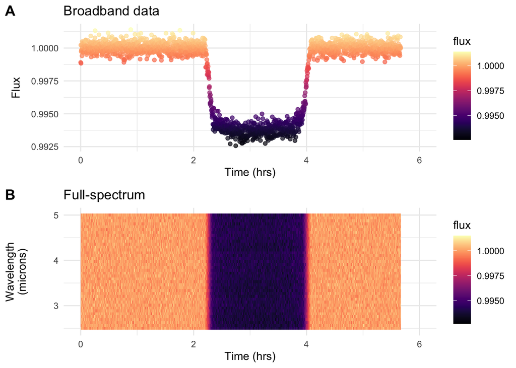

Figure 1: Flux recorded by James Webb Space Telescope over ~6 hour range on October 31, 2022 near Star GJ 3470. Bright (yellow/white) color indicates no obstruction between star and telescope. Dark (purple/black) inidicates transit of exoplanet GJ 3470b.

We first plot brightness against time for both broadband and full-spectrum data (Figure 1). To aid interpretation and make plot labels neater, we show time in hours starting from the beginning of dataset instead of Julian Date. Panel (A) shows the broadband signal that is combined over all wavelengths. Flux is plotted on the y-axis and time is plotted on the x-axis. Panel (B) shows the more granular “full-spectrum” of wavelengths. Both plots also show flux in color, with white/yellow indicating no transit (i.e. full light capture) and purple/black indicating transit (some light blocked, presumably by a transiting exoplanet). There is a clear dip in brightness starting after 2 hours and lasting until 4 hours.

Our findings are summarized below.

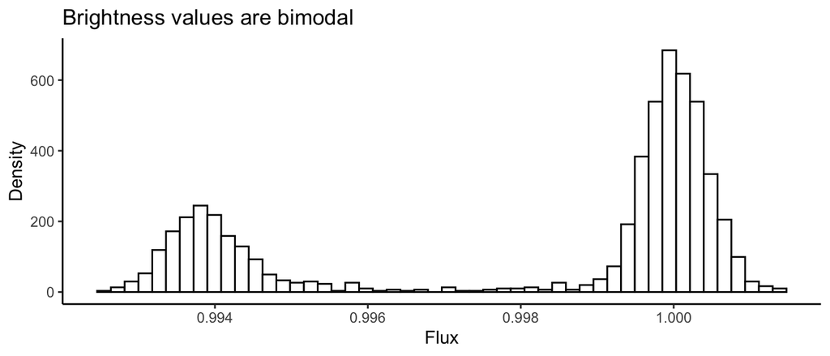

Figure 2: Histogram of broadband brightness (flux) values.

# Q1: Is There An Exoplanet Orbiting GJ 3470?

## Q1: Analytical Strategy

Let $Z_{\rm{no \; transit}}$ and $Z_{\rm{transit}}$ be two independent Gaussian distributions with corresponding means $\mu_1$ and $\mu_2$. Let $\pi$ be the probability of a datum belonging to the no transit component. If we call $X_i$ the flux values for time $i$, our probability model is written as below.

$$p(X_i = x_i) = \pi_i P(Z_{\rm{no \; transit}} = x_i) + (1 - \pi_i) P(Z_{\rm{ transit}} = x_i)$$

We fit the GMM using {mixtools}. Figure 3 shows the density of the two mixture components overlaid on the histogram of flux values. Model fit seems reasonable, with both modes being captured. In particular, the green curve represents the flux values recorded during transit of the exoplanet. The red curve captures points before and after the transit.

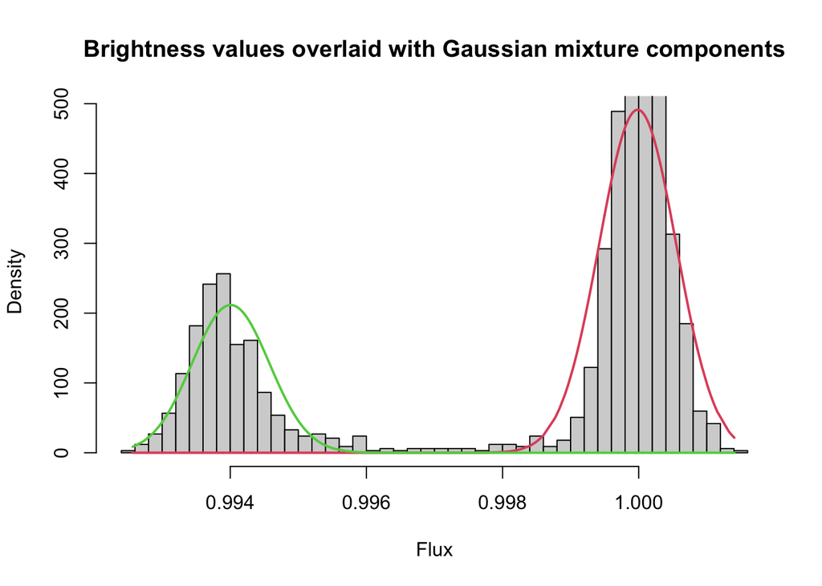

Figure 3: Density of broadband flux values with overlaid Gaussian Mixture Model (GMM). Green curve represents the component associated with transit; red curve represents the component before and after transit.

Testing whether there is an exoplanet is equivalent to testing whether we are justified in increasing the number of components of the GMM from one to two. This is similar in flavor to an Analysis of Variance (ANOVA), where we consider a simpler model with fewer parameters as the “null” model, and the full model with more parameters as the “alternative”. Likewise, our null model is that we have a GMM with one component. Our alternative is that we have a GMM with two components. More formally, we use a parametric bootstrap test with 1000 bootstrap samples under the one-component null model.

# Q2: What is the Depth and Duration of Transit?

## Q2 (i): How Deep is the Transit?

The transit depth (also called [fractional depth](https://www.open.edu/openlearn/mod/oucontent/view.php?id=74851&section=4.1)) is simply the fractional amount of light missing. Based on the above plots, we expect the amount of light missing to be noticeable, but fairly small (somewhere around 0.005-0.007). We use the below formula to calculate fractional depth.

$$\hat{\rm{Transit \; Depth}} = 1 - \hat{\mu_{\rm{Transit}}} = 1 - 0.9940064 \approx 0.006$$
In this formula, $\hat{\mu}_{\rm{Transit}}$ is the estimated mean of the Gaussian distribution associated with transit. The estimated transit depth is approximately 0.006. A 95% confidence interval is (0.0049, 0.0071).

## Q2 (ii): What is the Duration of the Transit?

To determine transit duration, we decide the boundaries of the transit event as earliest and latest time points that are in the transit component of the GMM. In other words, the start of transit is the earliest timepoint with a corresponding brightness being assigned to the transit component. The end is the last such point in the transit component. In this way, we can get a start and end point. This is also represented visually by the color switching from blue to yellow in Figure 4.

The transit begins at approximately 2.28 hours, ends at 3.98 hours, and lasts approximately 1.70 hours. This is equivalent to 7.08% of one earth day.

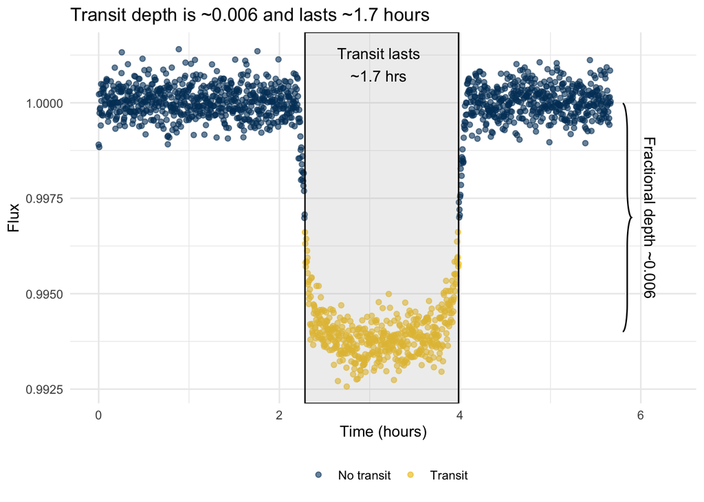

Figure 4: Brightness (flux) values (y-axis) plotted against time (x-axis). Color represents assignment to one of the two Gaussian mixture components. Blue is the baseline no-transit distribution. Yellow points belong to the transit event distribution.

# Q3: Is GJ 3470b Cloudy?

## Q3: Analytical Strategy

A Gaussian Mixture Model is fit to each of the 40 wavelengths as in Q1. The transit depth for each wavelength is estimated as $\hat{\rm{Transit \; Depth}_{wavelength}} = 1 - \hat{\mu_{\rm{Transit}_{wavelength}}}$. We then fit a linear model.

$$\hat{\rm{Transit \; Depth}} \sim \rm{Intercept} + \rm{Wavelength} + \epsilon$$

In the above model, $\epsilon$ represents the error term. We make the standard linear model assumptions: (i) that `Transit depth` is in fact a linear combination of the other variables, that the residuals are (ii) independent and (iii) drawn from a Gaussian distribution with constant variance.

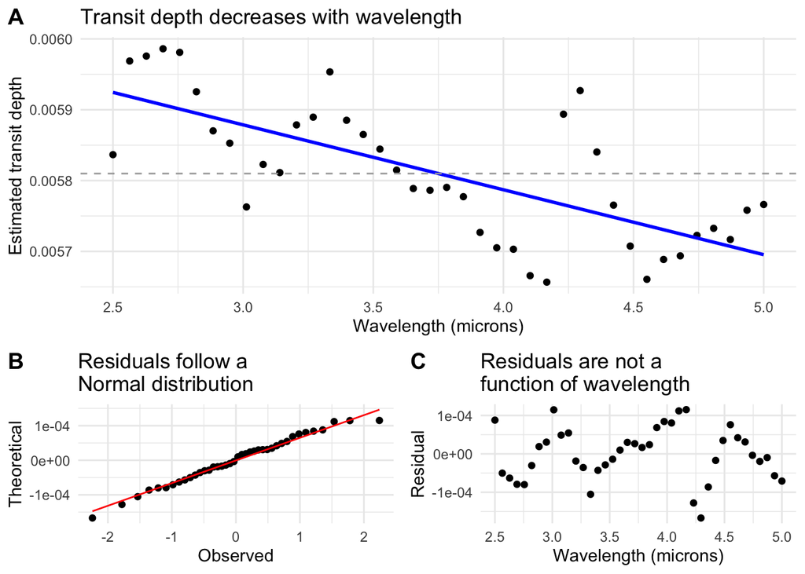

The adjusted $R^2$ for the model is 0.49 and $p < 10^{-6}$ associated with the `wavelength` predictor $\hat{\beta} = -9 \times 10^{-5}$. In other words, there is a significant association between wavelength and estimated transit depth. As you increase wavelength by one micron, we expect transit depth to decrease by $9\times 10^{-5}$. This indicates that depth is not independent of wavelength. This is evidence that the GJ 3470b is covered by clouds.

# Q4: Is There CO2 Present In The Atmosphere of the Exoplanet?

If there is a $\rm{CO}_2$, we would expect excess absorption of light. In other words, we are looking for a deeper (lower) transit at the wavelength corresponding to $\rm{CO}_2$, which is given as 4.29 microns.

## Q4: Analytical Strategy

We gather estimates of transit depth by computing $1 - \rm{flux}$ for the lightcurve corresponding to $\rm{CO}_2$ (4.29 microns) for each time point within the transit event. This gives us 503 depths. We repeat this process with two lightcurves just outside the $\rm{CO}_2$ absorption range: 4.1 and 4.55 microns. Since there are two wavelengths, we have 1006 values for the “outside the $\rm{CO}_2$ range” values. Call $\mu_{\rm{CO}_2}$ and $\mu_{\rm{Outside \; CO_2}}$ the respective means. Data are plotted in Figure 6 and show a separation in the means of the two distributions of depths.

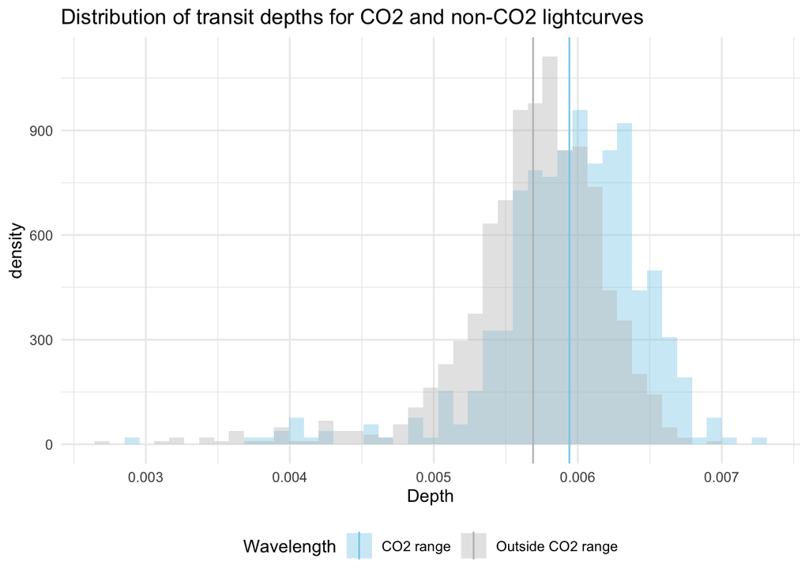

Figure 6: Density of transit depths estimated at each timepoint (1 - flux) during the duration of transit event. Grey indicates the distribution of depths for the two light curves not associated with CO2 (4.1 and 4.55 microns). Light blue indicates the distribution for the light curve associated with CO2 (4.29 microns). Estimated means for both are plotted as vertical lines.

We conduct a two-sample $t$-test and assume equal variances between the two groups of depths. Since we are looking for larger transit depth at the $\rm{CO}_2$ wave length, we consider the one-sided alternative. Our null hypothesis is depths associated with the $\rm{CO}_2$ wavelength are no greater than the non-$\rm{CO}_2$ wavelength depths: $H_0: \mu_{\rm{CO}_2} \leq \mu_{\rm{Outside \; CO_2}}$. Our alternative is that there is more light absorption for the $\rm{CO}_2$ wavelength: $H_A : \mu_{\rm{CO}_2} > \mu_{\rm{Outside \; CO_2}}$.

## Q4: Result - CO2 Is Present in the Atmosphere of GJ3470b

The one-sided test statistic is $t = 8.97$ with corresponding $p < 10^{-15}$. We reject the null at size $0.001$. There is sufficient evidence that the mean transit depth for the $\rm{CO}_2$ lightcurve is greater than the non-$\rm{CO}_2$ depths. In other words, there is sufficient evidence that there is $\rm{CO}_2$ in the atmosphere of the exoplanet GJ 3470b.

# Conlusion

## Discussion

Our use of Gaussian Mixture Models (GMMs) seems appropriate because flux values appeared bimodal and conditionally Normal. More complex models could make explicit use of time (e.g. using a changepoint detection model). Moreover, if the signal were noisier, GMMs may not be appropriate to separate the transit event from the rest of the data. Using our modeling framework on other transit events for different stars would be a good way to assess its appropriateness.

# Appendix

## Questions Prepared for Client

April 21, 2023

1. How was this star / exoplanet chosen?
2. Is it correct that the datasets only cover about one quarter of one day on earth?
3. What causes variability in the measurements? Measurement error in the telescope? Innate to the system
4. There is a one-to-one correspondence in the transit (collapsed) data between the flux and flux uncertainty. This is not the case for the more granular data. Why is that?
5. Can you say more about how the Poisson model was used? Is each cell (wavelength by time) an independent draw from a Poisson where the lambda is only a function of time?
6. Is it standard to transform flux data besides the scaling you’ve already performed? For example, log-transformation?
7. Are there any sanity checks we can perform? Reasonable values?
8. Can you give a sense of what a meaningful fractional depth would be? This is the percentage of light blocked?
9. How much correlation do you expect between neighboring wavelengths?
10. Is transit depth the same as fractional depth?